# COVID Cases

Leonid Rempel

05/08/2021

## Introduction

For this homework assignment, I will be forecasting the change in the number of positive COVID-19 cases in the US over all the time available. I originally wanted to look at vaccination rates (I will be receiving my second Pfizer dose on 05/09) but there has not been enough weeks since the beginning of the vaccination roll-out. Furthermore the daily data is not as interesting to forecast, it follows a smooth trend. The daily number of people fully vaccinated is taken from [covid tracking](https://covidtracking.com/data/download).

```r
df <- read.csv("national-history.csv")
```

We have 420 days of information, lets go ahead and make it into a weekly time series and plot it.

```r
weekly <- as.Date(cut(as.Date(df$date), "week"))
df <- aggregate(positiveIncrease ~ weekly, df, sum)

cases <- ts(df$positive,
         start = decimal_date(as.Date('2020-01-13')),
         frequency = 52)
```

When we aggregate based on the week we have 60 cases.

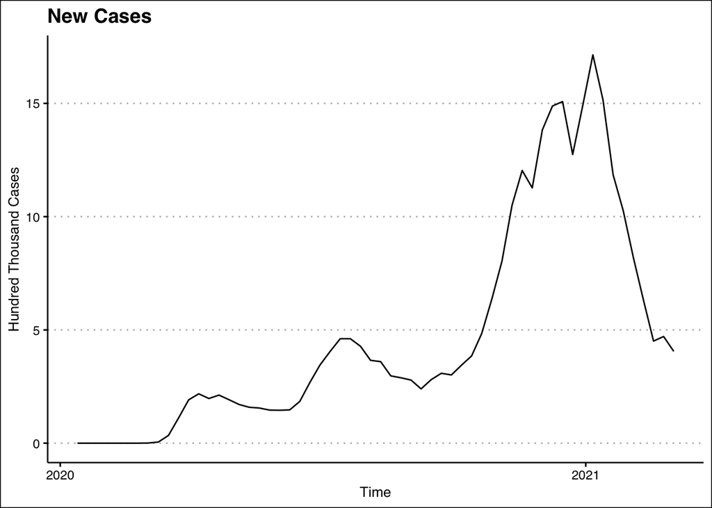

```r
autoplot(cases/1e5) +
  labs(title = 'New Cases',
       y = 'Hundred Thousand Cases',
       x = 'Time')
```

We seem to have a very smooth series, so something like exponential smoothing should do well, but lets look at the ACF and PACF breakdown first before fitting models.

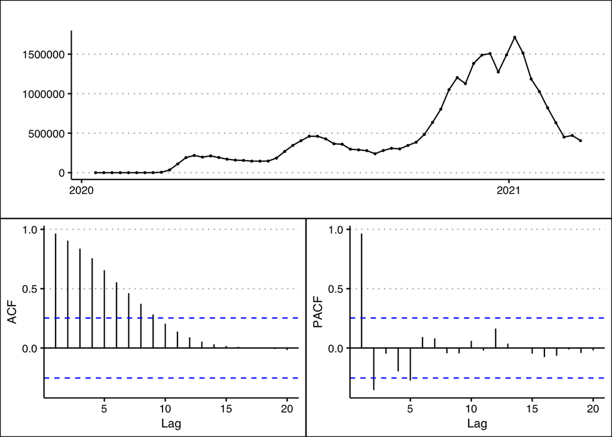

```r
ggtsdisplay(cases)
```

We can see that we will need at least one lag, and that there is probably a longer term sinusoidal ACF pattern.

Lets see what a BoxCox transformation would look like for the data.

```r
BoxCox.lambda(cases)
```

```
## [1] 1
```

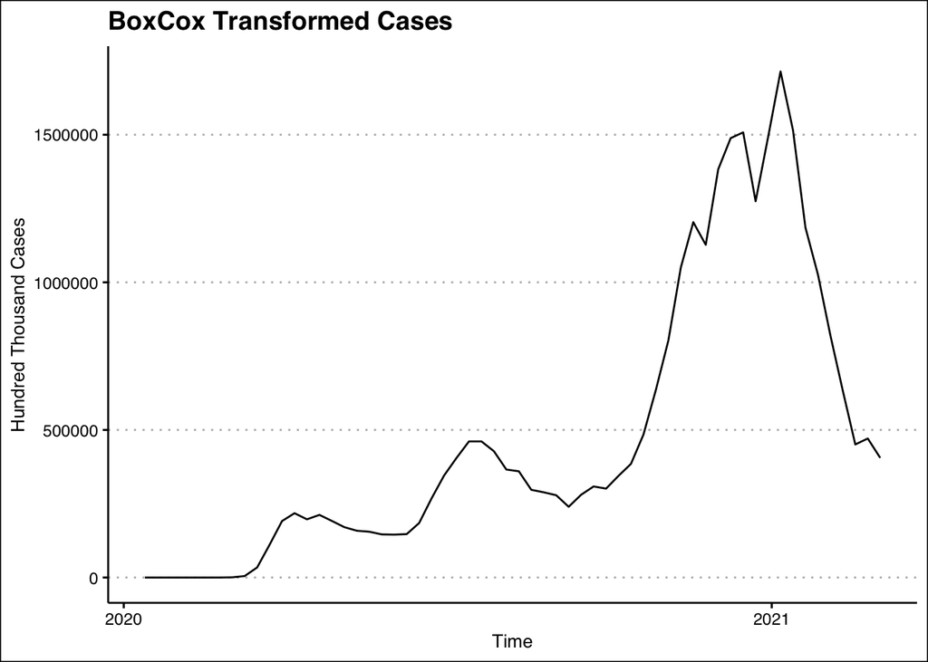

```r
autoplot(BoxCox(cases, BoxCox.lambda(cases)),
         main = 'BoxCox Transformed Cases',
         ylab = 'Hundred Thousand Cases')
```

The Box Cox doesnt seem to make much of a difference.

## ETS Fit

First lets see what kind of model an ETS would fit the data. We know that it will definitely have a trend component and likely an exponential smoothing component.

```r
ets.fit <- ets(cases/1e5)
```

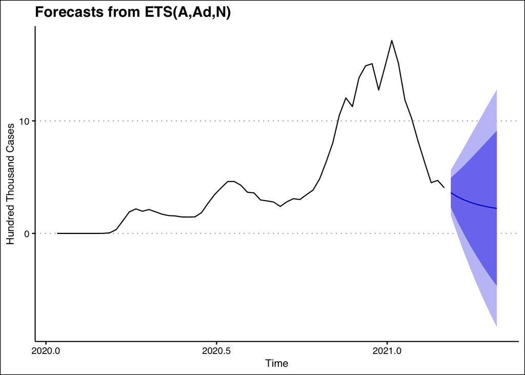

```r
autoplot(forecast(ets.fit, h = 8), ylab = 'Hundred Thousand Cases')
```

We can see that R chose an ETS model with a Additive errors and an Additive trend. Obviously we cannot have negative cases, but I will keep the cases that are around 1 and 0 from the start of 2020. Now lets record the results from the `tsCV()`

```r
ets.cv <- function(x, h) {
  forecast(ets(x, model = "AAN"), h=h)
}
mean(na.omit(tsCV(cases/1e5, ets.cv, h = 8)))**0.5
```

```
## [1] 0.1358023
```

## Arima Fit

```r
bestK <- 0
bestfit <- list(aicc=Inf)
for(i in 1:25) {
  fit <- auto.arima(cases/1e5, xreg=fourier(cases/1e5, K=i))
  if(fit$aicc < bestfit$aicc) {
    bestfit <- fit
    bestK <- i
  }
  else break;
}
bestK
```

```
## [1] 2
```

```r
bestfit
```

```
## Series: cases/1e+05
## Regression with ARIMA(0,1,1) errors
##
## Coefficients:
##          ma1    S1-52   C1-52    S2-52   C2-52
##       0.3605  -0.0723  2.8470  -1.3555  2.1339
## s.e.  0.1152   1.8783  1.9598   0.9675  0.9409
##
## sigma^2 estimated as 0.9183:  log likelihood=-78.66
## AIC=169.32   AICc=170.93   BIC=181.78
```

We only need 2 fourier terms to aid our ARIMA model.

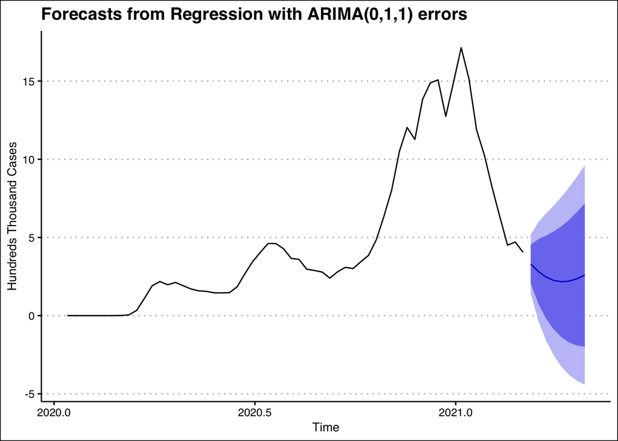

```r
autoplot(forecast(bestfit, xreg = fourier(cases, K=bestK, h = 8)),
         ylab = 'Hundreds Thousand Cases')
```

We have a deeper curve with the Fourier plus ARIMA error forecasts, lets see how its `tsCV()` compares with the `ets()` model.

```r
arima.cv <- function(x, h) {
  forecast(auto.arima(x, xreg = fourier(x, K=2)), h=h)
}
mean(na.omit(tsCV(cases/1e5, arima.cv, h = 8)))**0.5
```

```
## [1] 0.1686842
```

It performs worse than the `ets()` so we will stick to the `ets()` as we move on to our last model.

## Neural Net

The last model I wanted to explore was a neural net. First we fit a neural net model.

```r
neural.fit <- nnetar(cases/1e5)
neural.fit
```

```
## Series: cases/1e+05
## Model:  NNAR(5,1,4)[52]
## Call:   nnetar(y = cases/1e+05)
##
## Average of 20 networks, each of which is
## a 6-4-1 network with 33 weights
## options were - linear output units
##
## sigma^2 estimated as 4.781e-05
```

We have some information about the different weights placed on the different components of our time series.

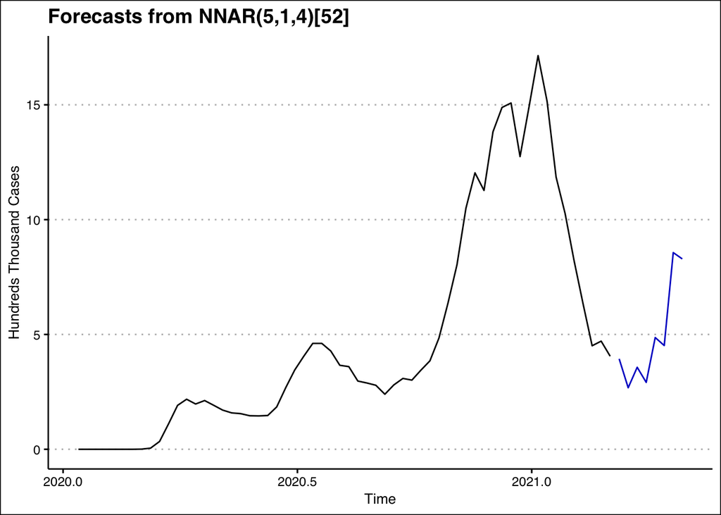

```r
autoplot(forecast(neural.fit, h = 8),
         ylab = 'Hundreds Thousand Cases')
```

```r
nnet.cv <- function(x, h) {
  forecast(nnetar(x, p=5, P=1), h=h)
}
mean(na.omit(tsCV(cases/1e5, nnet.cv, h = 8)))**0.5
```

```
## [1] 1.473574
```

## Final forecasts

Before we give the final forecasts, lets look at the residuals on the `ets()` model.

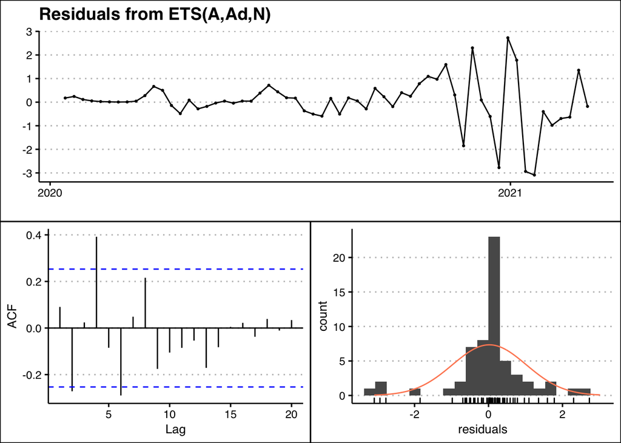

```
##
##  Ljung-Box test
##
## data:  Residuals from ETS(A,Ad,N)
## Q* = 29.075, df = 7, p-value = 0.0001402
##
## Model df: 5.   Total lags used: 12
```

```r
checkresiduals(ets.fit, lag = 12)
```

Lets try using the BoxCox transform from before.

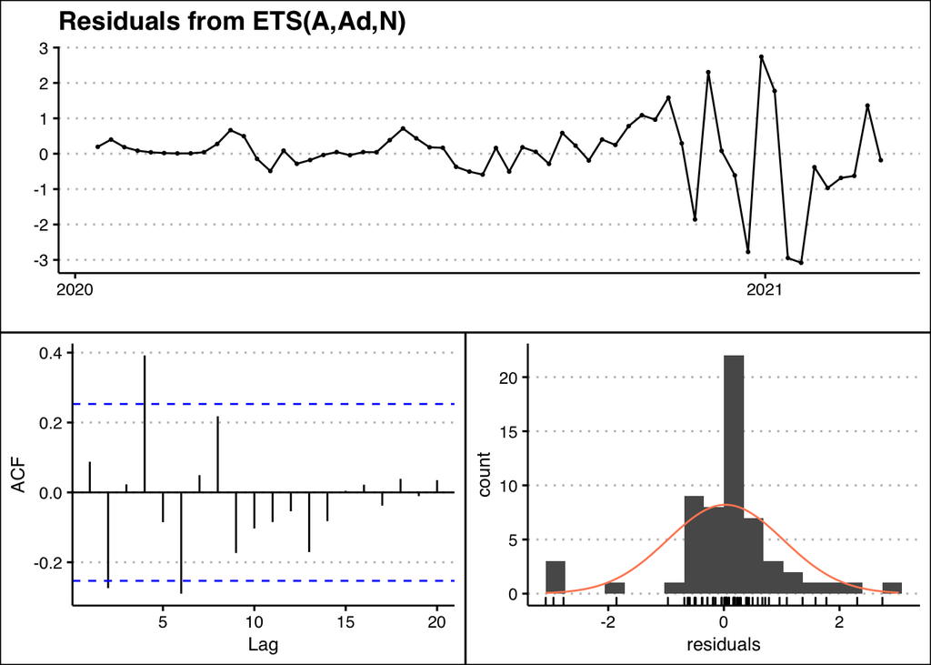

```
##
##  Ljung-Box test
##
## data:  Residuals from ETS(A,Ad,N)
## Q* = 29.137, df = 7, p-value = 0.0001366
##
## Model df: 5.   Total lags used: 12
```

```r
ets.fit.bx <- ets(cases/1e5, lambda = BoxCox.lambda(cases/1e5))
checkresiduals(ets.fit.bx)
```

We don’t have much of a difference as expected. This time I will try a fit by ignoring the first couple of months where the cases are under 100.

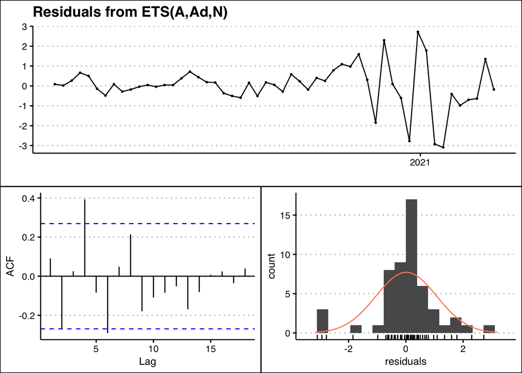

```
##
##  Ljung-Box test
##
## data:  Residuals from ETS(A,Ad,N)
## Q* = 26.078, df = 6, p-value = 0.0002153
##
## Model df: 5.   Total lags used: 11
```

```r
ets.fit.bx.2 <- ets(window(cases/1e5, start = c(2020, 9)),
                  lambda = BoxCox.lambda(window(cases/1e5, start = c(2020, 9))))
checkresiduals(ets.fit.bx.2)
```

Unfortunately we cannot get white noise residuals with this model. For lack of a better way to achieve this, we will go forward with the BoxCox outlier removed model for our forecasts.

```r
forecast(ets.fit.bx.2, h = 8)
```

```
##          Point Forecast      Lo 80    Hi 80      Lo 95     Hi 95
## 2021.187       3.612702  2.1957402 5.029665  1.4456457  5.779759
## 2021.206       3.260450  0.9053132 5.615587 -0.3414209  6.862321
## 2021.225       2.978648 -0.2803837 6.237680 -2.0056109  7.962907
## 2021.244       2.753206 -1.3848157 6.891229 -3.5753523  9.081765
## 2021.264       2.572853 -2.4165570 7.562263 -5.0577912 10.203498
## 2021.283       2.428570 -3.3819236 8.239065 -6.4578133 11.314954
## 2021.302       2.313144 -4.2867707 8.913059 -7.7805547 12.406843
## 2021.321       2.220803 -5.1366953 9.578302 -9.0315198 13.473126
```

For the next eight weeks, we can expect the number of new COVID cases to decrease steadily.

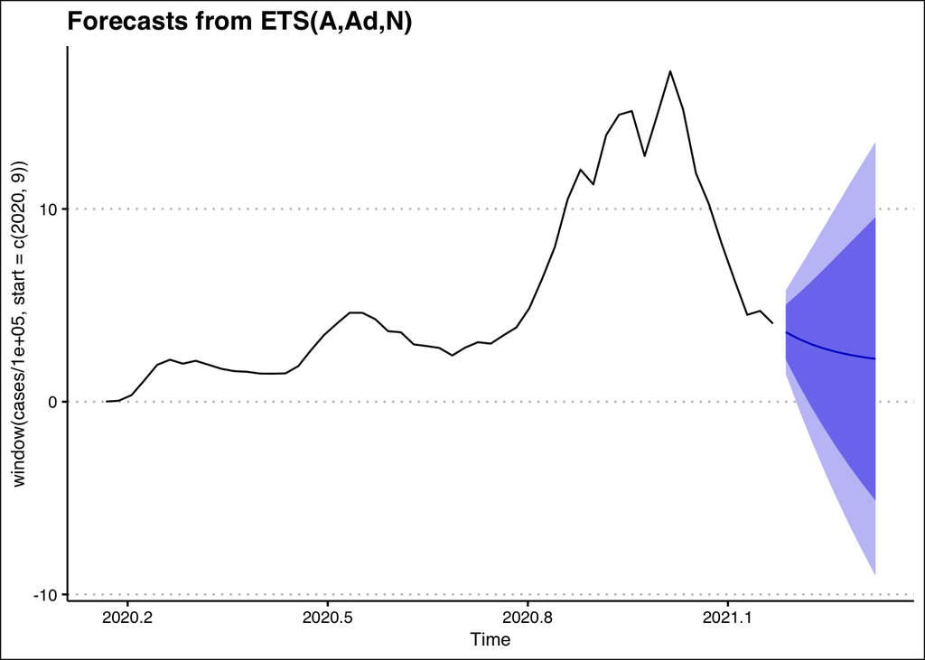

```r
autoplot(forecast(ets.fit.bx.2, h = 8))
```